# R Notebook

April 05, 2026

# 1 Introduction

Directional data is concerned with unit vectors observations on a circular plane or three dimensional space, rendering standard univariate and multivariate analysis methods obsolete (Mardia, XIX). Directional data is encountered in fields such as bioinformatics, collaborative filtering (Banerjee, 1346), and the analysis of text documents (Banerjee, 1348). Directional data can also be extended into three dimensions, with practical use of directional data arises in several situations. The directions of magnetism in rocks, directions from the Earth to stars, and directions of optical axes in quartz crystals are all best modeled using spherical statistics (Mardia, 175). Of particular importance to directional statistics is the von-Mises distribution, which is perhaps one of the most useful distributions for statistical inference the distribution most useful for statistical inference (Mardia, 36). The vMF distribution is analogous to the well-known Gaussian, or normal distribution (Banerjee, 1350 and Sra, 179), sharing many common properties. Similarly to the normal distribution, the vMF distribution takes in two main parameters. one, the mean direction μ, which is the average point at which vectors are concentrated, and two, the concentration parameter, k, which is how tightly points are clustering around that mean direction.

Despite being one of the most basic probability distributions for multi-dimensional directional statistics, estimating the maximum likelihood for the vMF distribution is difficult due to a transcendental (non closed form) equation that needs to be solved in order to compute the concentration parameter (Sra, 1). This parameter can be approximated through several means, namely the Banerjee, Tanabe, and Newton methods. These methods have various advantages and disadvantages. The Banerjee method has the advantage of not using function evaluations, and therefore being the fastest out of the three; however, it’s accuracy is the least reliable. The Tanabe and Newton methods both are significantly slower, but more accurate. In particular, the Newton method is the most accurate.

Of particular importance to analyzing vMF models is mixing multiple vMF distributions, which allows for multiple clusters of data that point in different directions with varying levels of concentration. Clustering algorithms often use the generative model framework, applying the expectation maximization algorithm. Estimating the concentration parameter k for each of these individual components has been of crucial importance, as it would yield better results, particularly for difficult clustering tasks in higher dimensional spaces (Banerjee, 1345).

In order to fit these vMF models (estimate the parameters of them in order to best explain the data), the Expectation-Maximization, or EM algorithm, is used. VMF models that only have a single distribution do not require the EM algorithm; however, the EM algorithm becomes crucial when there are clusters of data, meaning various vMF models are mixed together. The expectation stage of the EM model computes the probability each data point came from a certain cluster, then during the maximization stage attempts to best update the parameters of each vMF distribution in order to best fit the data (Hornik). In Hornik and Grun’s movMF, an R package using the EM algorithm has been created with the aim of fitting vMF mixtures: “The R package movMF contains functionality to draw samples from finite mixtures of von Mises-Fisher distributions and to fit these models using the expectation-maximization algorithm for maximum likelihood estimation” (Hornik, 1). Various examples of use are given, such as clustering text documents (Hornik, 24), which can group components within a document based on the detection of certain keywords.

# 2 R Environment Setup

```r
# Installing needed packages
library(movMF)
library(Directional)
```

```r
library(ggplot2)
```

Setting a seed allows us to recreate the data generated here, rather than having different data every time the file is ran.

```r
set.seed(144)
```

# 3 Simulation: Generating vMF Data in 3D

In order to a handle on what simulated vMF data is like, we use two datasets here for some small initial tests. The first is a “basic” set of parameters that generate simple vMF data to work with, and the second is a “challenge” set of parameters that makes more difficult vMF data to work with.

The parameters we are working with are as follows:  
- mu: The mean direction unit vectors are pointing in. This cannot be made more difficult, and all mu values will be of equal complexity for movMF to work with.  
- kappa: The measure of how strongly data is concentrated around the mean direction. A lower value means lower concentration, making it more difficult for movMF to estimate the mean direction. A value of 0 would even mean complete dispersion of unit vectors, with no adherence to the mean direction whatsoever. A higher concentration means increasing adherence to the mean direction.  
- n: The number of unit vectors we are working with. Higher values of n means a greater sample size for movMF to work with, creating more ease of estimating the mean direction.

## 3.1 Creating Parameter set: Basic

```r
# A very "normal" set of parameters for a vMF analysis.
mu_base <- c(0, 0, 1) # mean direction
kappa_base <- 10
n_base <- 200

# Normalizing base parameters
mu_base_norm <- sqrt(sum(mu_base^2))
mu_base_norm
```

```
## [1] 1
```

```r
# Checking if mu is normalized. If not, it is normalized
mu_base <- mu_base / sqrt(sum(mu_base^2))
mu_base
```

```
## [1] 0 0 1
```

## 3.2 Creating Parameter set: Challenge

```r
# A more challenging set of parameters for a vMF analysis, with less concentration and a smaller sample size
mu_challenge <- c(0, 0, 1)
kappa_challenge <- 5
n_challenge <- 50

# Normalizing challenge parameters
mu_challenge_norm <- sqrt(sum(mu_challenge^2))
mu_challenge_norm
```

```
## [1] 1
```

```r
# Checking if challenge mu is normalized. If not, it is normalized
mu_challenge <- mu_challenge / sqrt(sum(mu_challenge^2))
mu_challenge
```

```
## [1] 0 0 1
```

# 4 Data Simulation

## 4.1 Simulating base vMF distribution data

```r
X_base <- rmovMF(n_base, mu_base, kappa_base)
head(X_base)
```

```
##             [,1]       [,2]       [,3]
## [1,] -0.05383935 -0.6327235 0.77250389
## [2,] -0.35749031  0.3183847 0.87797032
## [3,] -0.08272079  0.5232232 0.84817144
## [4,] -0.36628308  0.9298494 0.03488235
## [5,]  0.12639553 -0.1517769 0.98029993
## [6,] -0.28913545  0.9024412 0.31937526
```

```r
print("length: " )
```

```
## [1] "length: "
```

```r
print(length(X_base)/3)
```

```
## [1] 200
```

We need to always sanity check this because vectors must be unit length. If not, k estimations will not function.

```r
lens_base <- sqrt(rowSums(X_base^2))
summary(lens_base)
```

```
##    Min. 1st Qu.  Median    Mean 3rd Qu.    Max.
##       1       1       1       1       1       1
```

We repeat this process with challenge vMF data.

```r
X_challenge <- rmovMF(n_challenge, mu_challenge, kappa_challenge)
head(X_challenge)
```

```
##             [,1]          [,2]        [,3]
## [1,]  0.29955599 -0.9298326476  0.21372284
## [2,] -0.68593358  0.5286995745  0.49997188
## [3,] -0.44862790 -0.0009193653  0.89371817
## [4,]  0.26627232 -0.9616645587 -0.06557688
## [5,] -0.18868013  0.6124335958  0.76767500
## [6,]  0.01554194  0.8822697056  0.47048763
```

```r
lens_challenge <- sqrt(rowSums(X_challenge^2))
summary(lens_challenge)
```

```
##    Min. 1st Qu.  Median    Mean 3rd Qu.    Max.
##       1       1       1       1       1       1
```

# 5 Visualization

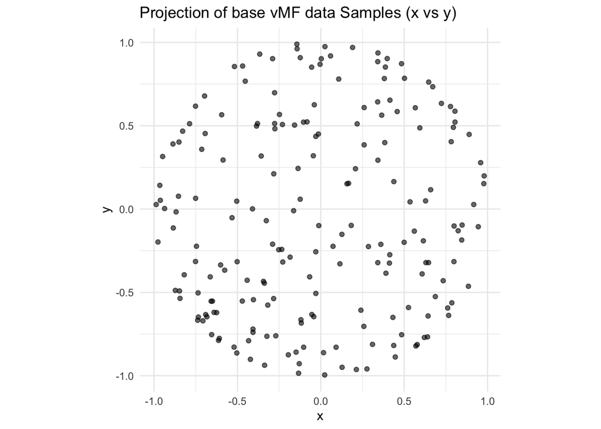

```r
df <- data.frame(x = X_base[,1], y = X_base[,2], z = X_base[,3])

ggplot(df, aes(x, y)) +
  geom_point(alpha = 0.6) +
  coord_equal() +
  theme_minimal() +
  labs(title = "Projection of base vMF data Samples (x vs y)", x = "x", y = "y")
```

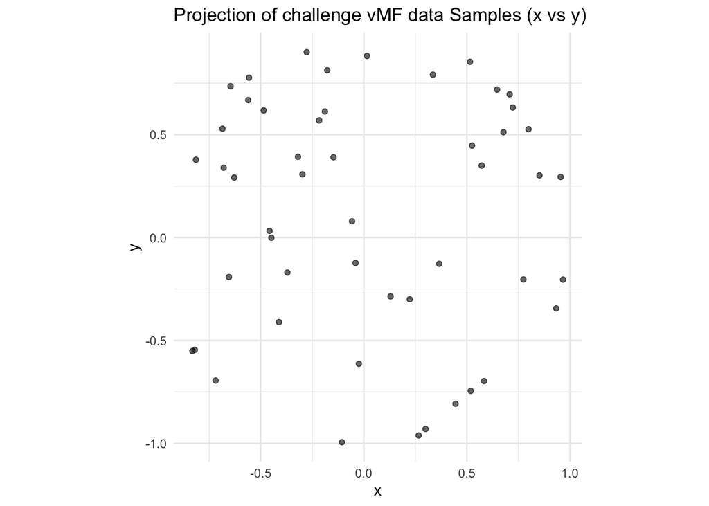

```r
df <- data.frame(x = X_challenge[,1], y = X_challenge[,2], z = X_challenge[,3])

ggplot(df, aes(x, y)) +
  geom_point(alpha = 0.6) +
  coord_equal() +
  theme_minimal() +
  labs(title = "Projection of challenge vMF data Samples (x vs y)", x = "x", y = "y")
```

In both x vs. y charts, there seems to be no particular pattern to the data. This is to be expected, as the points only cluster towards z = 1, and are indifferent to x and y coordinates.

```
## Ignoring unknown labels:
## • z : "z"
```

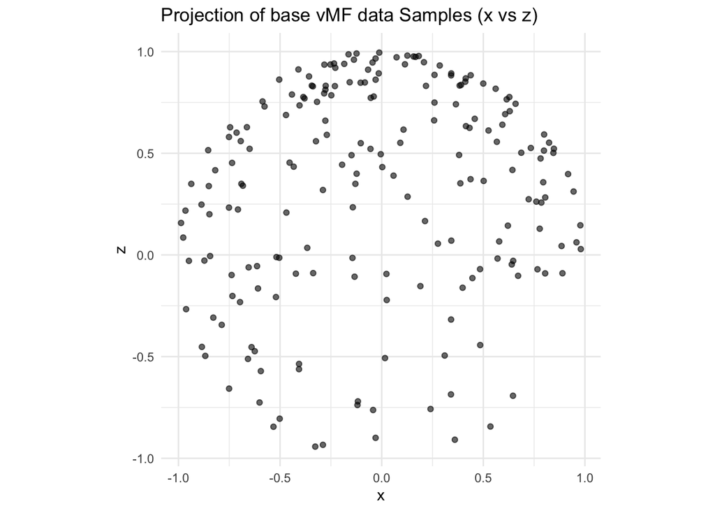

```r
df <- data.frame(x = X_base[,1], y = X_base[,2], z = X_base[,3])

ggplot(df, aes(x, z)) +
  geom_point(alpha = 0.6) +
  coord_equal() +
  theme_minimal() +
  labs(title = "Projection of base vMF data Samples (x vs z)", x = "x", z = "z")
```

```
## Ignoring unknown labels:
## • z : "z"
```

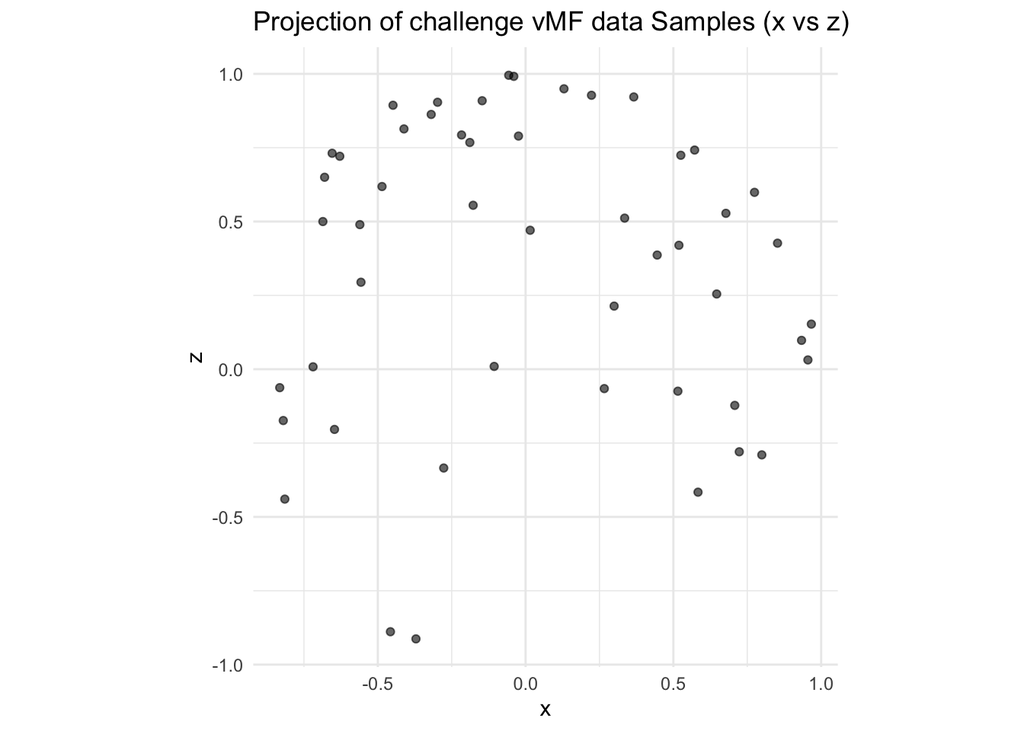

```r
df <- data.frame(x = X_challenge[,1], y = X_challenge[,2], z = X_challenge[,3])

ggplot(df, aes(x, z)) +
  geom_point(alpha = 0.6) +
  coord_equal() +
  theme_minimal() +
  labs(title = "Projection of challenge vMF data Samples (x vs z)", x = "x", z = "z")
```

Now we can see a clear pattern of concentration towards z = 1, even in the less concentrated challenge data set.

```
## Ignoring unknown labels:
## • z : "z"
```

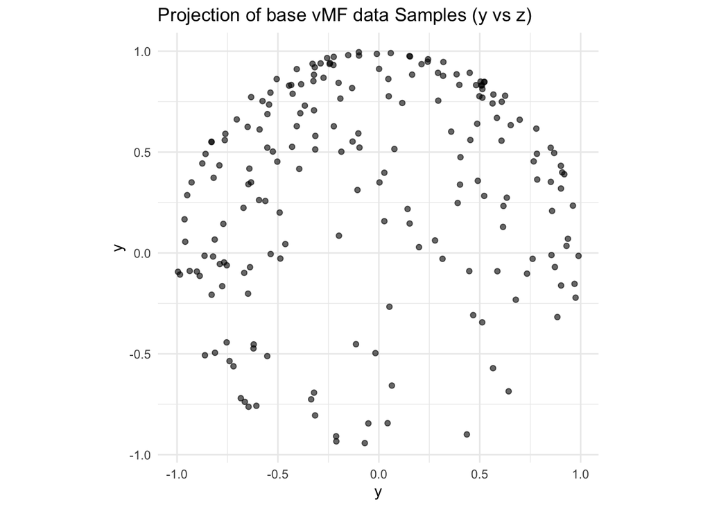

```r
df <- data.frame(x = X_base[,1], y = X_base[,2], z = X_base[,3])

ggplot(df, aes(y, z)) +
  geom_point(alpha = 0.6) +
  coord_equal() +
  theme_minimal() +
  labs(title = "Projection of base vMF data Samples (y vs z)", y = "y", z = "z")
```

```
## Ignoring unknown labels:
## • z : "z"
```

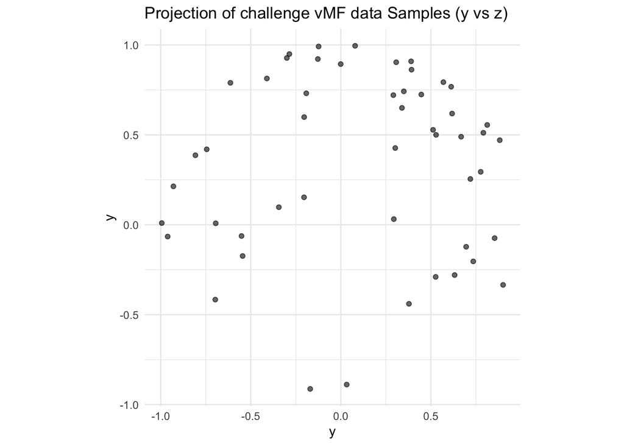

```r
df <- data.frame(x = X_challenge[,1], y = X_challenge[,2], z = X_challenge[,3])

ggplot(df, aes(y, z)) +
  geom_point(alpha = 0.6) +
  coord_equal() +
  theme_minimal() +
  labs(title = "Projection of challenge vMF data Samples (y vs z)", y = "y", z = "z")
```

With Y vs Z data, a similar pattern holds. However, a 3D project will give us the most human-readable view of how the data is dispersed.

## 5.1 3D Projection (Interactive)

```r
library(rgl)
open3d()
```

```
## glX
##   1
```

```r
plot3d(X_base, col = "blue", size = 5)
rglwidget()
```

[interactive chart not shown]

```r
library(rgl)
open3d()
```

```
## glX
##   3
```

```r
plot3d(X_challenge, col = "blue", size = 5)
rglwidget()
```

[interactive chart not shown]

# 6 Parameter Estimation

## 6.1 Estimation of mean

First we estimate the sample mean, which must be normalized:

$$\hat{\mu} = \frac{\bar{x}}{\|\bar{x}\|}$$

```r
# Estimating base mean
mu_base_hat_raw <- colMeans(X_base)
mu_base_hat <- mu_base_hat_raw / sqrt(sum(mu_base_hat_raw^2))
mu_base_hat
```

```
## [1] -0.08132286 -0.17569168  0.98108054
```

```r
# Estimating challenge mean
mu_challenge_hat_raw <- colMeans(X_challenge)
mu_challenge_hat <- mu_challenge_hat_raw / sqrt(sum(mu_challenge_hat_raw^2))
mu_challenge_hat
```

```
## [1] 0.06602838 0.30238753 0.95089539
```

As we can see here, the challenge mean seems slightly more varied from the true mean of (0, 0, 1). The x coordinate is coincidentally less far off - but the y, and most importantly z, coordinates are a bit further off.

## 6.2 Measurement of errors via angles

We can measure the error between true mu and the estimated one by taking the angle between the vectors.

```r
mu_base_true <- mu_base

# Angle between vectors
angle_base_rad <- acos(sum(mu_base_true * mu_base_hat))
angle_base_deg <- angle_base_rad * 180 / pi

list(
  mu_base_true = mu_base_true,
  mu_base_hat = mu_base_hat,
  base_angle_degrees= angle_base_deg
)
```

```
## $mu_base_true
## [1] 0 0 1
##
## $mu_base_hat
## [1] -0.08132286 -0.17569168  0.98108054
##
## $base_angle_degrees
## [1] 11.16295
```

```r
mu_challenge_true <- mu_challenge

# Angle between vectors
angle_challenge_rad <- acos(sum(mu_challenge_true * mu_challenge_hat))
angle_challenge_deg <- angle_challenge_rad * 180 / pi

list(
  mu_challenge_true = mu_challenge_true,
  mu_challenge_hat = mu_challenge_hat,
  challenge_angle_degrees= angle_challenge_deg
)
```

```
## $mu_challenge_true
## [1] 0 0 1
##
## $mu_challenge_hat
## [1] 0.06602838 0.30238753 0.95089539
##
## $challenge_angle_degrees
## [1] 18.02985
```

As expected, the angle of error is greater with the challenge set.

## 6.3 Estimation of concentration

movMF can attempt to estimate the concentration variable K, which is the foremost variable being studied and approximated.

```r
# Setting k to 1 fits a single vMF distribution. Therefore, the E step in the EM algorithm is skipped - every point will belong to the same component. Only the M step is used.
fit1 <- movMF(X_base, k = 1)
fit1
```

```
## theta:
##          [,1]       [,2]     [,3]
## 1 -0.08358973 -0.1805891 1.008428
## alpha:
## [1] 1
## L:
## [1] 31.87115
```

```r
kappa_base_hat <- norm(fit1$theta, "2")
mu_base_hat_mle <- fit1$theta/kappa_base_hat

list(
  # Estimation of mean
  mu_base_hat_mle = mu_base_hat_mle,
  # Estimation of kappa
  kappa_base_hat = kappa_base_hat
)
```

```
## $mu_base_hat_mle
##          [,1]       [,2]      [,3]
## 1 -0.08132286 -0.1756917 0.9810805
##
## $kappa_base_hat
## [1] 1.027875
```

```r
fit2 <- movMF(X_challenge, k = 1)
fit2
```

```
## theta:
##         [,1]      [,2]     [,3]
## 1 0.07912418 0.3623618 1.139492
## alpha:
## [1] 1
## L:
## [1] 10.47518
```

```r
kappa_challenge_hat <- norm(fit2$theta, "2")
mu_challenge_hat_mle <- fit2$theta/kappa_challenge_hat

list(
  # Estimation of mean
  mu_challenge_hat_mle = mu_challenge_hat_mle,
  # Estimation of kappa
  kappa_challenge_hat = kappa_challenge_hat
)
```

```
## $mu_challenge_hat_mle
##         [,1]      [,2]      [,3]
## 1 0.06602838 0.3023875 0.9508954
##
## $kappa_challenge_hat
## [1] 1.198336
```

# 7 Experiment 1 - Sample Size

In this study, we examine the effect of sample size on movRF’s ability to predict concentration. Every sample size from 50 to 1000 in increments of 10 is studied, and a plot is made to see how accuracy increases with increasing sample size.

```r
sample_sizes <- seq(from = 50, to = 1000, by = 10)

results_base <- data.frame(
  n = sample_sizes,
  kappa_hat = NA_real_,
  angle_deg = NA_real_
)

for (i in 1:length(sample_sizes)) {
  n_i <- sample_sizes[i]
  theta_true <- 50 * mu_base # Note that, in the movRF package, we merge mu and kappa together; so mu_base * 50 becomes [0, 0, 50] here.
  Xn <- rmovMF(n_i, theta_true)

  # estimate mu and angle error
  mu_hat_raw <- colMeans(Xn)
  mu_hat_n <- mu_hat_raw / sqrt(sum(mu_hat_raw^2))
  angle_n <- acos(sum(mu_base * mu_hat_n)) * 180 / pi

  # estimate kappa via MLE
  fit_n <- movMF(Xn, k = 1)

  results_base$kappa_hat[i] <- norm(fit_n$theta,"2")
  results_base$angle_deg[i] <- angle_n
}
```

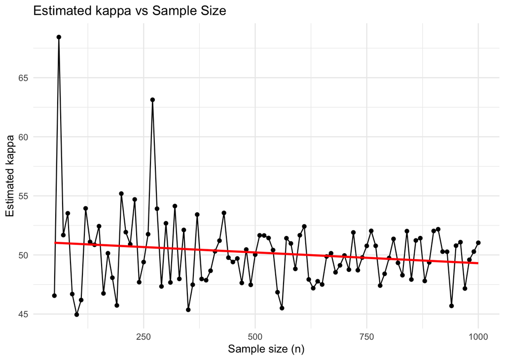

```r
ggplot(results_base, aes(x = n, y = kappa_hat)) +
  geom_point() +
  geom_line() +
  geom_smooth(method = "lm", se = FALSE, color = "red") +
  theme_minimal() +
  labs(title = "Estimated kappa vs Sample Size",
       x = "Sample size (n)",
       y = "Estimated kappa")
```

Perhaps even more useful is plotting angle of error against sample size. Here, the angle of error is clearly decreasing to an almost negligible amount over time.

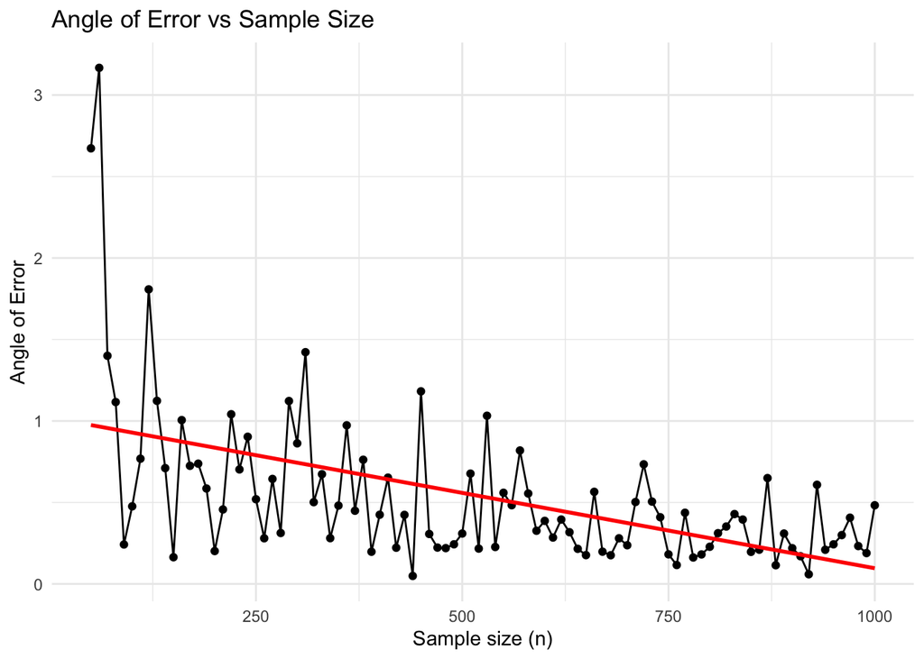

```r
ggplot(results_base, aes(x = n, y = angle_deg)) +
  geom_point() +
  geom_line() +
  geom_smooth(method = "lm", se = FALSE, color = "red") +
  theme_minimal() +
  labs(title = "Angle of Error vs Sample Size",
       x = "Sample size (n)",
       y = "Angle of Error")
```

# 8 Experiment 2 - Concentration

We repeat the last experiment, but keep sample size fixed on two values: 25 and 100. The role of the concentration itself in movRF attempt to estimate the concentration is studied.

## 8.1 Sample size of 25

```r
kappas <- seq(from = 10, to = 300, by = 5)

results_kappa_25 <- data.frame(
  n = NA_real_,
  kappa = kappas,
  angle_deg = NA_real_
)

for (i in 1:length(kappas)){
  n <- 25
  theta_true <- kappas[i] * mu_base
  Xn <- rmovMF(n, theta_true)

  # estimate mu and angle error
  mu_hat_raw <- colMeans(Xn)
  mu_hat_n <- mu_hat_raw / sqrt(sum(mu_hat_raw^2))
  angle_n <- acos (sum(mu_base * mu_hat_n)) * 180 / pi

  # estimate kappa via MLE
  fit_n <- movMF(Xn, k = 1)
  results_kappa_25$kappa_hat[i] <- norm(fit_n$theta, "2")
  results_kappa_25$angle_deg[i] <- angle_n
}
```

We now plot the estimate of concentration. This time, we just focus on the decrease of angle of error over time.

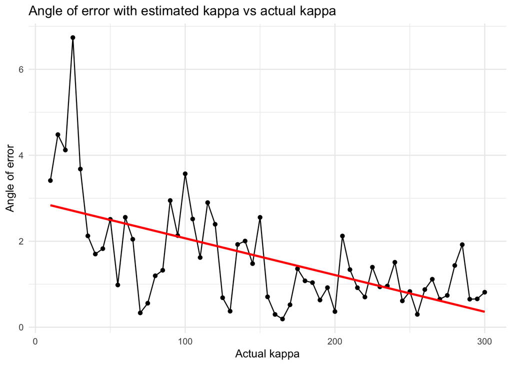

```r
ggplot(results_kappa_25, aes(x = kappa, y = angle_deg)) +
  geom_point() +
  geom_line() +
  geom_smooth(method = "lm", se = FALSE, color = "red") +
  theme_minimal() +
  labs(title = "Angle of error with estimated kappa vs actual kappa",
       x = "Actual kappa",
       y = "Angle of error")
```

As we can see, there is immense variation - however, even with this small sample size, the angle of error seems to inevitably decrease.

## 8.2 Sample size of 100

```r
kappas <- seq(from = 10, to = 300, by = 5)

results_kappa_100 <- data.frame(
  n = NA_real_,
  kappa = kappas,
  angle_deg = NA_real_
)

for (i in 1:length(kappas)){
  n <- 100
  theta_true <- kappas[i] * mu_base
  Xn <- rmovMF(n, theta_true)

  # estimate mu and angle error
  mu_hat_raw <- colMeans(Xn)
  mu_hat_n <- mu_hat_raw / sqrt(sum(mu_hat_raw^2))
  angle_n <- acos (sum(mu_base * mu_hat_n)) * 180 / pi

  # estimate kappa via MLE
  fit_n <- movMF(Xn, k = 1)
  results_kappa_100$kappa_hat[i] <- norm(fit_n$theta, "2")
  results_kappa_100$angle_deg[i] <- angle_n
}
```

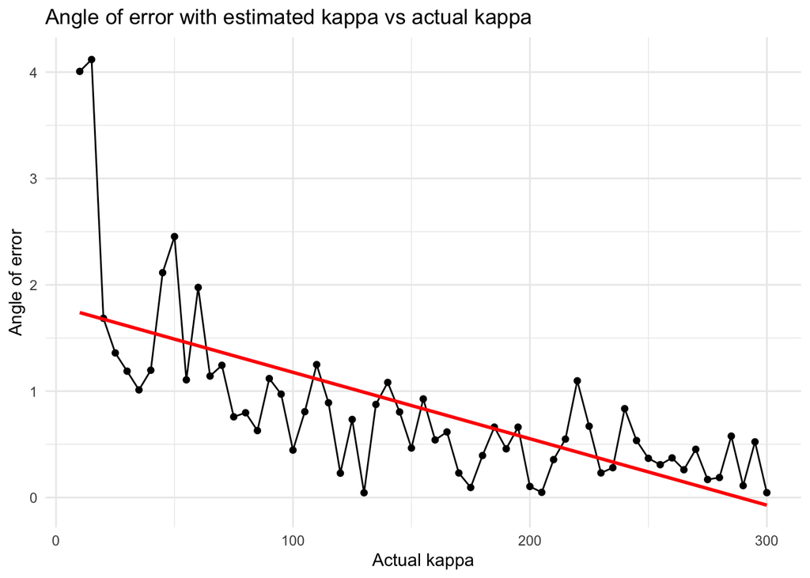

```r
ggplot(results_kappa_100, aes(x = kappa, y = angle_deg)) +
  geom_point() +
  geom_line() +
  geom_smooth(method = "lm", se = FALSE, color = "red") +
  theme_minimal() +
  labs(title = "Angle of error with estimated kappa vs actual kappa",
       x = "Actual kappa",
       y = "Angle of error")
```

With a larger sample size, the graph seems to be less “jagged”, and most angles of error do not exceed 1.

# 9 Experiment 3 - Varied Sample Sizes and Concentration

```r
sample_sizes <- seq(50, 1050, length.out = 20)
kappas <- seq(10, 210, length.out = 10)

# Declaring a grid that will hold all angles of error.
param_grid <- expand.grid(
  n = sample_sizes,
  kappa = kappas
)
param_grid$angle_deg <- NA_real_

for (i in seq_len(nrow(param_grid))) {
  theta_true <- param_grid$kappa[i] * mu_base
  Xn <- rmovMF(param_grid$n[i], theta_true)

  mu_hat_raw <- colMeans(Xn)
  mu_hat <- mu_hat_raw / sqrt(sum(mu_hat_raw^2))

  param_grid$angle_deg[i] <-
    acos(sum(mu_base * mu_hat)) * 180 / pi
}
```

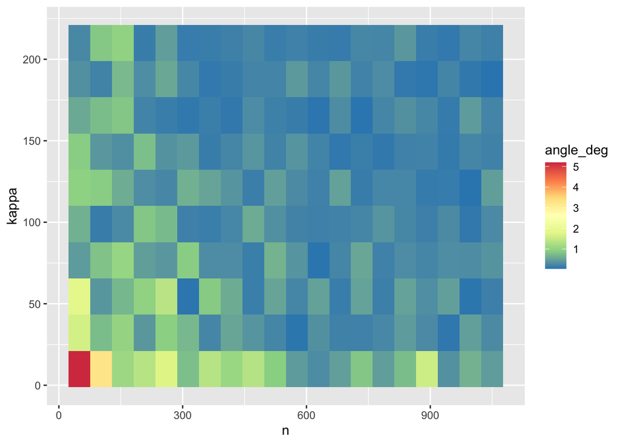

```r
ggplot(param_grid, aes(x = n, y = kappa, fill = angle_deg)) + geom_tile() + scale_fill_distiller(palette = "Spectral")
```

As one expects, increasing sample size and concentration increase the accuracy of movRF. However, there isn’t that clear of a pattern here as to which parameter is more crucial to accuracy. A slight pattern seems to exist where smaller sample size (0 - 300) data sets are more likely to have higher degree of errors compared to small kappa (0 - 50) data sets - however, more analysis is needed to establish a well defined pattern.

# 10 Interpretation and Writing

[output not shown]